# CS107_final

Hong Zhu

April 30, 2016

There are many animals ending up in shelters every year. 35% (2.7 millions out of 7.6 millions) of dogs and cats are euthanized by the shelter due to no adoptions for long or disease, and the rest of them are able to be adopted, transferred or returned to owners by animal adopter. We believe that some animals required more help than others to find a adopter. Currently, the animal shelters are using experience or knowledge to make a subjective judgement to decide it, such as their looking, age and size. However, we can use more information including breed, color, sex, name to make a better judgement. For example, we want to research the relationship between a pet’s outcome and whether it has name. If we are seeing pets with names have more probability to find permanent home, we should suggest animal shelters spent more time on naming pets. Whether a pet has a name or not is just one factor of this project, and we will use Machine Learning and Regression to help animal shelter find key factors that impact the outcomes of animals in a quantified way.

Kaggle is hosting a competition since March 21, 2016 to help improve outcomes for shelter animals, in which more than 300 teams participate to predict the outcome of each animal using a dataset of intake information including breed, color, sex, and age from the Austin Animal Center from October 1st, 2013 to March, 2016. The insights could help shelters focus their energy on specific animals who need extra help finding a good adopter.

At the mean time, Kaggle will provide test data, and all submissions are evaluated using the multi-class logarithmic loss.

```r
library(lubridate)
library(gridExtra)
library(ggplot2)
library(dplyr)
setwd("/Users/hongzhu/Desktop")
train<-read.csv("train.csv")
```

# EDA and Visualization

To understand the data, I did data wrangling, data visualization, and some other exploratory data analysis at the beginning.

## A) Research Name/Age of animals and their outcomes

At first, I notice that in the Name column, there are some lots of missing values. In other words, many of the animals in animal shelter do not have names, so I create a new column hasname to show whether animal has name or not. 1 means has name, and 0 means does not have a name.

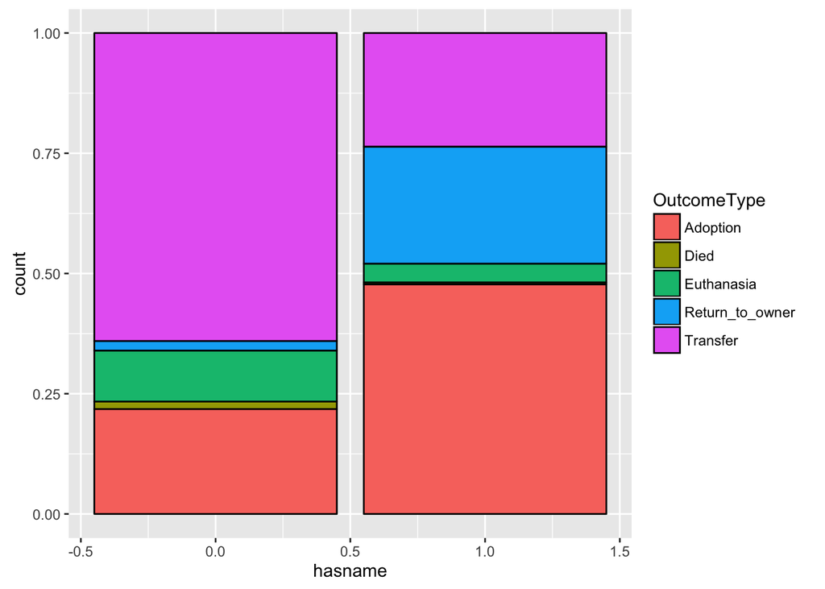

```r
train$Name=as.character(train$Name)
train=train %>% mutate(hasname=ifelse(nchar(Name)==0,0,1))
train2<-train
train %>% group_by(hasname,OutcomeType) %>% summarize(count=n()) %>%
  ggplot(aes(x = hasname, y = count, fill = OutcomeType)) +
  geom_bar(stat = 'identity', position = 'fill',colour="black")
```

We can see that the animals who have names have much more probability to be adopted. Then, I want to research on the relationshop between hasname and the age of animals. I have an assumption that younger animals might have lower probability to have a name, since they may be to young to be given a name by animal shelter.

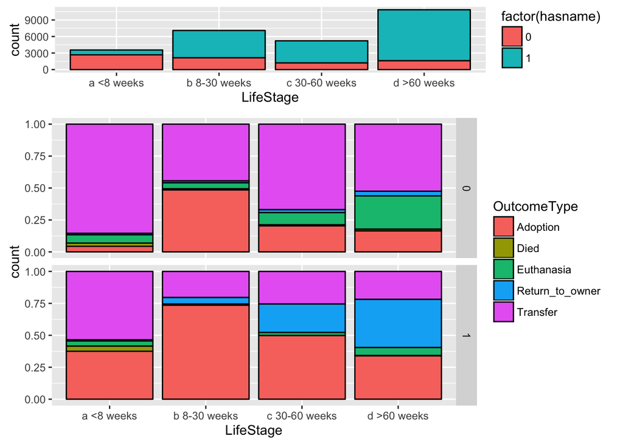

```r
train$AgeuponOutcome=as.character(train$AgeuponOutcome)
train$AgeValue <- sapply(train$AgeuponOutcome, function(x) strsplit(x, split =' ')[[1]][1])
train$AgeUnit <- sapply(train$AgeuponOutcome, function(x) strsplit(x, split =' ')[[1]][2])
train$AgeValue  <- as.numeric(train$AgeValue)
train$AgeUnit <- as.factor(train$AgeUnit)
train$AgeUnit <- gsub('s', '', train$AgeUnit)
UnitTrans <- ifelse(train$AgeUnit == 'day', 1/7, ifelse(train$AgeUnit == 'week', 1,
              ifelse(train$AgeUnit == 'month', 4, ifelse(train$AgeUnit == 'year', 52, NA))))

train$AgeWeeks <- train$AgeValue * UnitTrans

train$LifeStage[train$AgeWeeks<=8]<-"a <8 weeks"
train$LifeStage[train$AgeWeeks %in% c(8:30)]<-"b 8-30 weeks"
train$LifeStage[train$AgeWeeks %in% c(30:60)]<-"c 30-60 weeks"
train$LifeStage[train$AgeWeeks >=60]<-"d >60 weeks"
train %>% group_by(LifeStage,hasname, OutcomeType) %>% summarize(count=n()) %>%
  ggplot(aes(x = LifeStage, y = count, fill = OutcomeType)) +
  geom_bar(stat = 'identity', position = 'fill',colour="black") +
  facet_grid(hasname~.) ->g1
train %>% group_by(LifeStage,hasname) %>% summarize(count=n()) %>%
  ggplot(aes(x = LifeStage, y = count,fill = factor(hasname))) +
  geom_bar(stat = 'identity', colour="black") ->g2
grid.arrange(g2,g1,ncol=1,heights=c(1,3))
```

We can tell from the plot that younger animals (animals younger than 8 weeks) have lower probability to have names, it should be because employees in animal center were too busy to give a newly-born animal a name. However, an animal younger than 8 weeks will have a much better chance to be adopted and lower chance to be transferred if it has a name. It is not surprising to see from the top graph that animals have much higher probability to have a name as they grow up, however, we are seeing the same pattern that animals with names are much more easily to be adopted on animals in all life stages. In addition, senior animals (animals older than 60 weeks) without names have much higher probability to be euthanized in animal shelter. I assume that it should be easier for potential adopters to have connections with animals with names, since animals may be trained to response if people call their names.

Given such different outcomes between animals with names and without names, I would recommend animal shelters spend time in naming animals and train them by calling their names, especially for senior animals and baby animals (animals in the first and fourth life stages).

## B) Research TimeUponOutcome of animals and their outcomes

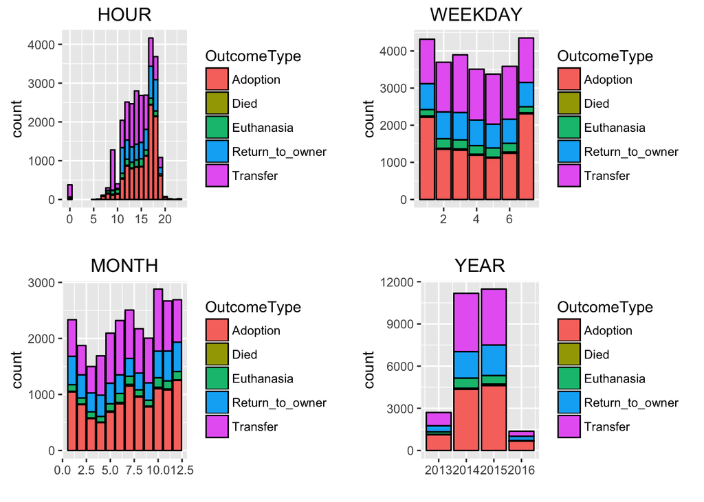

```r
train$Hour    <- hour(train$DateTime)
train$Weekday <- wday(train$DateTime)
train$Month   <- month(train$DateTime)
train$Year    <- year(train$DateTime)
train %>% group_by(Hour,OutcomeType) %>% summarize(count=n()) %>%
  ggplot(aes(x = Hour, y = count,fill = OutcomeType)) +
  geom_bar(stat = 'identity', colour="black")+ggtitle("HOUR")+xlab("")->g_hour
train %>% group_by(Weekday,OutcomeType) %>% summarize(count=n()) %>%
  ggplot(aes(x = Weekday, y = count,fill = OutcomeType)) +
  geom_bar(stat = 'identity', colour="black")+ggtitle("WEEKDAY")+xlab("") ->g_weekday
train %>% group_by(Month,OutcomeType) %>% summarize(count=n()) %>%
  ggplot(aes(x = Month, y = count,fill = OutcomeType)) +
  geom_bar(stat = 'identity', colour="black")+ggtitle("MONTH")+xlab("") ->g_month
train %>% group_by(Year,OutcomeType) %>% summarize(count=n()) %>%
  ggplot(aes(x = Year, y = count,fill = OutcomeType)) +
  geom_bar(stat = 'identity', colour="black")+ggtitle("YEAR")+xlab("") ->g_year
grid.arrange(g_hour,g_weekday,g_month,g_year,ncol=2,heights=c(1,1))
```

In the plots above, I split TimeUponOutcome column into year, month, weekday and hour. We can see some interesting points in here.

## C) Research AnimalTypes and their outcomes

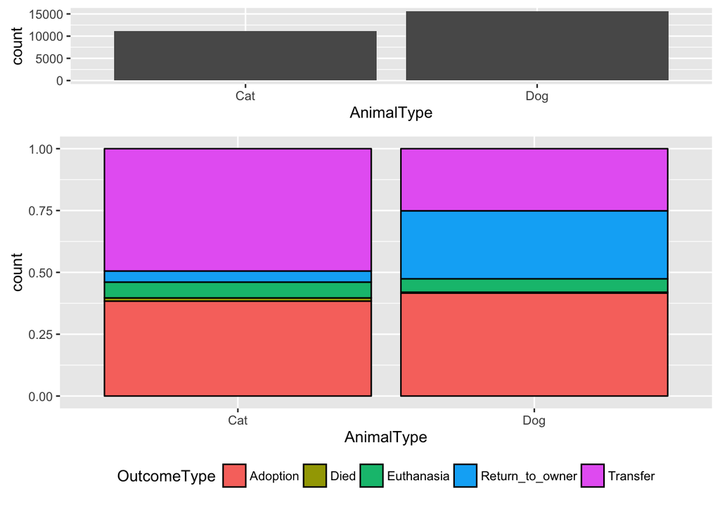

```r
#Animal Type and Outcome
train %>% group_by(AnimalType,OutcomeType) %>% summarize(count=n()) %>%
  ggplot(aes(x = AnimalType, y = count,fill = OutcomeType)) +
  geom_bar(stat = 'identity',position = 'fill', colour="black")+ theme(legend.position="bottom") ->g_animal1

train %>% group_by(AnimalType) %>% summarize(count=n()) %>%
  ggplot(aes(x = AnimalType, y = count)) + geom_bar(stat="identity") ->g_animal2

grid.arrange(g_animal2,g_animal1,ncol=1,heights=c(1,3))
```

We have more dogs than cats in this given dataset. Dogs and cats have equal chance to be adopted, but dogs have higher chance to be returned to owner and lower chance to be transferred to others than cats.

## D) Research Sex/Intactness and their outcomes

Both male and female animals have similar chance to have all kinds of outcomes.

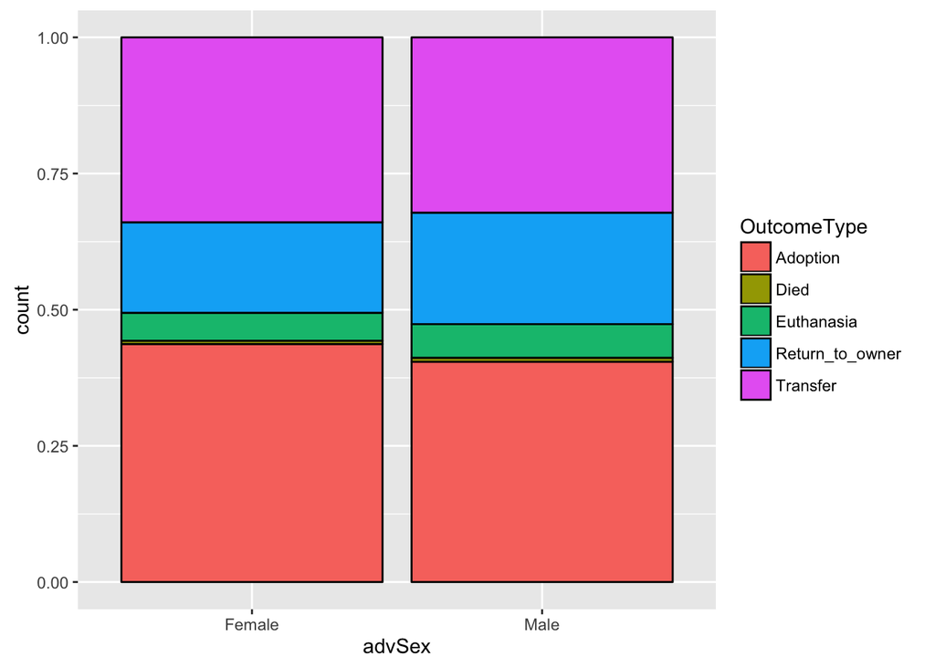

```r
train$SexuponOutcome=as.character(train$SexuponOutcome)
train$advSex <- sapply(train$SexuponOutcome, function(x) strsplit(x, split =' ')[[1]][2])
train %>% group_by(advSex,OutcomeType) %>% summarize(count=n()) %>%
  ggplot(aes(x = advSex, y = count,fill = OutcomeType)) +
  geom_bar(stat = 'identity',position="fill", colour="black")
```

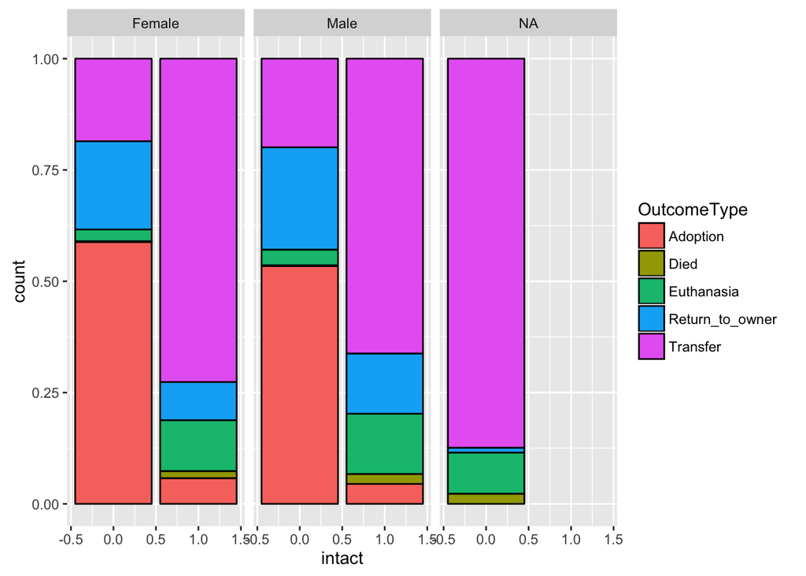

```r
train$intact_tmp <- sapply(train$SexuponOutcome, function(x) strsplit(x, split =' ')[[1]][1])
train$intact=ifelse(train$intact_tmp=="Intact",1,0)
train %>% group_by(intact,advSex,OutcomeType) %>% summarize(count=n()) %>%
  ggplot(aes(x = intact, y = count,fill = OutcomeType)) +
  geom_bar(stat = 'identity',position="fill", colour="black")+facet_grid(.~advSex)
```

## E) 80-20 Rule in Color and Breed of Animals

In training data, all animals share 366 colors and 1380 breeds in total. However, these colors and breeds are not equally spreaded among all animals, I figured an 80-20 rule existing in the distribution of breeds and colors: the majority animals have very small amount of breeds and colors.

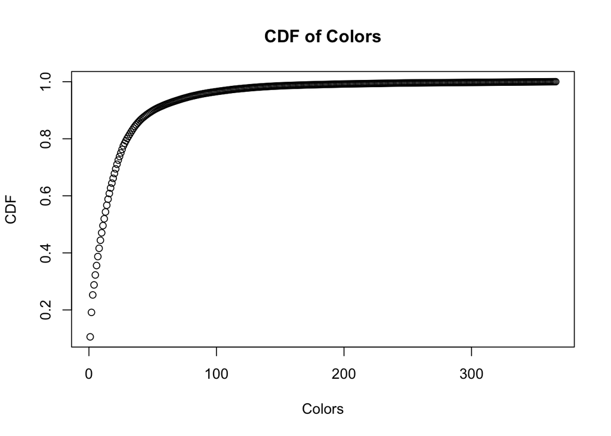

```r
#Color
tmp_pdf<-list()
tmp<-train %>% group_by(Color) %>% summarize(count=n()) %>% arrange(desc(count)) %>% mutate(pct=count/sum(count))
for (i in c(1:nrow(tmp))){
  pdf_tmp<-sum(tmp$pct[1:i])
  tmp_pdf[i]<-pdf_tmp
}
tmp$pdf<-unlist(tmp_pdf)
plot(tmp$pdf,ylab="CDF",xlab="Colors",main="CDF of Colors")
```

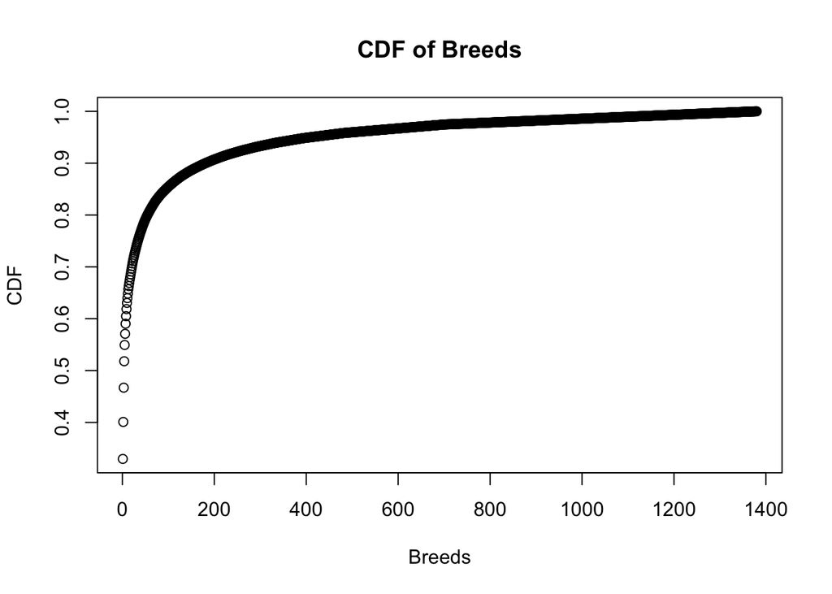

```r
#Breed
tmp_pdf_b<-list()
tmp_b<-train %>% group_by(Breed) %>% summarize(count=n()) %>% arrange(desc(count)) %>% mutate(pct=count/sum(count))
for (i in c(1:nrow(tmp_b))){
  pdf_tmp_b<-sum(tmp_b$pct[1:i])
  tmp_pdf_b[i]<-pdf_tmp_b
}
tmp_b$pdf<-unlist(tmp_pdf_b)
plot(tmp_b$pdf,ylab="CDF",xlab="Breeds",main="CDF of Breeds")
```

# Data Modeling

Get both train and test data from Kaggle, since we need to do data wrangling on both of them in the same way.

```r
setwd("/Users/hongzhu/Desktop")
train_data<-read.csv("train.csv")
test_data<-read.csv("test.csv")
```

## Data Wrangling for Train and Test Data

### 1) Data Preparation

- We need to check if test and train data given by Kaggle having all names and breed overlapped, otherwise if there is some names or breeds only included in test data but not in train data, it will give us some difficulties to do prediction.

```r
BreedSummary=table(c(as.character(train_data$Breed),as.character(test_data$Breed)))
trainNameSummary <- table(c(as.character(train_data$Name),as.character(test_data$Name)))
```

- Delete data we do not need for data modeling, such as AnimalID and Subtype of outcome which is not given in test data

```r
train_data$AnimalID=NULL
test_data$ID=NULL
train_data$OutcomeSubtype=NULL
```

### 2) Data Wrangling

- For animal name

First, created hasname for both test data and train data

```r
train_data=train_data %>% mutate(hasname=ifelse(nchar(as.character(Name))==0,0,1))
test_data=test_data %>% mutate(hasname=ifelse(nchar(as.character(Name))==0,0,1))
```

Second, create namepop to measure the popularity of a name, with assumption that animals has most and least popular name might be easiler to be adopted.

```r
train_data$namepop <- trainNameSummary[match(train_data$Name,names(trainNameSummary))]
test_data$namepop <- trainNameSummary[match(test_data$Name,names(trainNameSummary))]
```

Third, create namelength to measure the length of animal names, with assumption that animals have shorter names might be easier to be adopted.

```r
train_data$namelength <- nchar(as.character(train_data$Name))
test_data$namelength <- nchar(as.character(test_data$Name))
#delete Name columns from train and test data
test_data$Name=NULL
train_data$Name=NULL
```

- For animal breed

I create breedpop to measure the popularity of a breed, with assumption that animals of rare breed are easier to be adopted.

```r
train_data$breedpop <- BreedSummary[match(train_data$Breed,names(BreedSummary))]
test_data$breedpop <- BreedSummary[match(test_data$Breed,names(BreedSummary))]
train_data$Breed=NULL
test_data$Breed=NULL
```

- For animal age

I unify AgeuponOutcome that are in different units with the same unit (week), then create a new column AgeWeeks.

```r
train_data$AgeuponOutcome=as.character(train_data$AgeuponOutcome)
train_data$AgeValue <- sapply(train_data$AgeuponOutcome, function(x) strsplit(x, split =' ')[[1]][1])
train_data$AgeUnit <- sapply(train_data$AgeuponOutcome, function(x) strsplit(x, split =' ')[[1]][2])
train_data$AgeValue  <- as.numeric(train_data$AgeValue)
train_data$AgeUnit <- as.factor(train_data$AgeUnit)
train_data$AgeUnit <- gsub('s', '', train_data$AgeUnit)
UnitTrans <- ifelse(train_data$AgeUnit == 'day', 1/7, ifelse(train_data$AgeUnit == 'week', 1,
                                                        ifelse(train_data$AgeUnit == 'month', 4, ifelse(train_data$AgeUnit == 'year', 52, NA))))
train_data$AgeWeeks <- train_data$AgeValue * UnitTrans
train_data$AgeValue=NULL
train_data$AgeUnit=NULL
train_data$AgeuponOutcome=NULL
```

I need to unify units in test data too.

```r
##############test data#################
test_data$AgeuponOutcome=as.character(test_data$AgeuponOutcome)
test_data$AgeValue <- sapply(test_data$AgeuponOutcome, function(x) strsplit(x, split =' ')[[1]][1])
test_data$AgeUnit <- sapply(test_data$AgeuponOutcome, function(x) strsplit(x, split =' ')[[1]][2])
test_data$AgeValue  <- as.numeric(test_data$AgeValue)
test_data$AgeUnit <- as.factor(test_data$AgeUnit)
test_data$AgeUnit <- gsub('s', '', test_data$AgeUnit)
UnitTrans <- ifelse(test_data$AgeUnit == 'day', 1/7, ifelse(test_data$AgeUnit == 'week', 1,
                                                             ifelse(test_data$AgeUnit == 'month', 4, ifelse(test_data$AgeUnit == 'year', 52, NA))))
test_data$AgeWeeks <- test_data$AgeValue * UnitTrans
test_data$AgeValue=NULL
test_data$AgeUnit=NULL
test_data$AgeuponOutcome=NULL
```

- For animal time upon outcome

I split TimeuponOutcome in to hour, month and weekday.

```r
train_data$Hour    <- hour(train_data$DateTime)
train_data$Weekday <- wday(train_data$DateTime)
train_data$Month   <- month(train_data$DateTime)
train_data$Year    <- year(train_data$DateTime)
test_data$Hour    <- hour(test_data$DateTime)
test_data$Weekday <- wday(test_data$DateTime)
test_data$Month   <- month(test_data$DateTime)
test_data$Year    <- year(test_data$DateTime)
train_data$DateTime=NULL
test_data$DateTime=NULL
```

- For animal sex

Split sex and intactness

```r
train_data$SexuponOutcome=as.character(train_data$SexuponOutcome)
train_data$advSex <- sapply(train_data$SexuponOutcome, function(x) strsplit(x, split =' ')[[1]][2])
test_data$SexuponOutcome=as.character(test_data$SexuponOutcome)
test_data$advSex <- sapply(test_data$SexuponOutcome, function(x) strsplit(x, split =' ')[[1]][2])
train_data$intact_tmp <- sapply(train_data$SexuponOutcome, function(x) strsplit(x, split =' ')[[1]][1])
train_data$intact=ifelse(train_data$intact_tmp=="Intact",1,-1)
train_data$intact[which(train_data$intact_tmp=="Unknown")]=0
train_data$intact[which(is.na(train_data$intact))]=0
train_data$advSex[which(is.na(train_data$advSex))]="Unknown"
test_data$intact_tmp <- sapply(test_data$SexuponOutcome, function(x) strsplit(x, split =' ')[[1]][1])
test_data$intact=ifelse(test_data$intact_tmp=="Intact",1,-1)
test_data$intact[which(test_data$intact_tmp=="Unknown")]=0
test_data$intact[which(is.na(test_data$intact))]=0
test_data$advSex[which(is.na(test_data$advSex))]="Unknown"
train_data$intact_tmp=NULL
test_data$intact_tmp=NULL
train_data$SexuponOutcome=NULL
test_data$SexuponOutcome=NULL
```

- For Color

Create three columes is_black, is_white, and multi-color.

```r
train_data$multi_color=0
train_data$multi_color[grep("Tri",train_data$Color)]=1
train_data$multi_color[grep("/",train_data$Color)]=1
test_data$multi_color=0
test_data$multi_color[grep("Tri",test_data$Color)]=1
test_data$multi_color[grep("/",test_data$Color)]=1
train_data$has_black=0
train_data$has_black[grep("Black",train_data$Color)]=1
test_data$has_black=0
test_data$has_black[grep("Black",test_data$Color)]=1
train_data$has_white=0
train_data$has_white[grep("White",train_data$Color)]=1
test_data$has_white=0
test_data$has_white[grep("White",test_data$Color)]=1
```

### 3) Deal with missing values

```r
#fill missing values
train_data$AgeWeeks[which(is.na(train_data$AgeWeeks))]=0
test_data$AgeWeeks[which(is.na(test_data$AgeWeeks))]=0
#factor advsex column
train_data$advSex=factor(train_data$advSex)
test_data$advSex=factor(test_data$advSex)
```

## Variable Selection

```r
library(randomForest)
training_indice=sample(c(1:nrow(train_data)),round(nrow(train_data)*0.8))
testing_indice=setdiff(c(1:nrow(test_data)),training_indice)
rf_model=randomForest(factor(OutcomeType)~AnimalType+namepop+namelength+
                        breedpop+AgeWeeks+Hour+Weekday+Month+Year+advSex+
                        intact+has_black+has_white+multi_color,
                      data=train_data[training_indice,],ntree=2800,importance=TRUE)
importance(rf_model)
```

```
##              Adoption      Died Euthanasia Return_to_owner  Transfer
## AnimalType   57.23056 37.683247  17.446902     165.3976188  76.15340
## namepop      57.91376  5.853345  52.073340      51.4014521  63.75986
## namelength   54.95291  2.573689  47.831635      58.0928206  58.72475
## breedpop     54.14298 -1.594293   3.533080      55.2943558 113.04037
## AgeWeeks    155.12864 60.077563  91.648067     341.0390146 224.62877
## Hour        180.86555 51.275321  27.555826      80.8603282 264.42957
## Weekday      91.09867 10.346610  14.204636      26.5464425 135.73736
## Month        33.92377 18.071979   8.431834      12.8131056 138.79134
## Year         20.49937 21.534881  19.224318       9.1602875 123.60087
## advSex       29.43134 14.255594   8.283523       8.7659390  33.98548
## intact      447.35156 72.644828 132.836518       2.9019515 174.54225
## has_black    13.34901  2.018337   9.202690       0.5291823  25.80585
## has_white    34.95925  1.720575   1.737884      -2.3406709  53.23774
## multi_color  43.12833 -3.777387   4.738862     -13.1412689  48.97953
##             MeanDecreaseAccuracy MeanDecreaseGini
## AnimalType             116.39669         287.8029
## namepop                 85.81776        1438.0703
## namelength              79.46417        1147.5804
## breedpop               152.20156        1191.1269
## AgeWeeks               338.24778        2158.4091
## Hour                   295.94803        1575.5255
## Weekday                140.55442         928.0999
## Month                  121.39789        1049.6765
## Year                   107.09585         507.2669
## advSex                  38.93476         285.7102
## intact                 285.34634        1686.9655
## has_black               25.55620         275.3107
## has_white               61.21379         247.5208
## multi_color             60.33873         220.9827
```

## Cross Validation Function

```r
#evaluation function
MultiLogLoss <- function(act, pred){
  eps = 1e-15;
  nr <- nrow(pred)
  pred = matrix(sapply( pred, function(x) max(eps,x)), nrow = nr)
  pred = matrix(sapply( pred, function(x) min(1-eps,x)), nrow = nr)
  act_matrix=matrix(0,nrow=length(act),ncol=ncol(pred))
  for(i in c(1:length(act))){
    act_matrix[i,as.numeric(act[i])]=1
  }
  #ll = sum(act_matrix*log(pred) + (1-act_matrix)*log(1-pred))
  ll = sum(act_matrix*log(pred))
  ll = ll * -1/nr
  return(ll)
}
```

# Model Builidng

- Random Forest

```r
library(randomForest)
training_indice=sample(c(1:nrow(train_data)),round(nrow(train_data)*0.8))
testing_indice=setdiff(c(1:nrow(test_data)),training_indice)
rf_model=randomForest(factor(OutcomeType)~AnimalType+namepop+namelength+
                        breedpop+AgeWeeks+Hour+Weekday+Month+Year+advSex+
                        intact+has_black+has_white+multi_color,
                      data=train_data[training_indice,],ntree=2800,importance=TRUE)
importance(rf_model)
```

```
##              Adoption      Died Euthanasia Return_to_owner  Transfer
## AnimalType   57.43817 34.852244  20.330305      174.504498  72.04053
## namepop      52.54772  3.218652  53.324451       52.245623  65.90433
## namelength   51.33707  4.928239  47.985083       55.725450  59.51613
## breedpop     49.88644 -1.359748  12.372956       57.392920 102.26530
## AgeWeeks    144.00883 61.249666 115.321687      348.332756 229.93445
## Hour        186.09733 48.891316  29.640851       78.999686 260.07600
## Weekday      93.08217  7.920101  10.225313       34.605267 138.28297
## Month        37.44431 16.381108   6.280579       11.573847 139.49727
## Year         22.71004 19.783612  19.010640       11.760601 127.35317
## advSex       30.71948 12.642908  14.171649       15.327984  34.94989
## intact      444.62892 70.148116 136.060889       -2.664985 166.12795
## has_black    17.68151 -3.073646   8.146424        2.996111  23.86448
## has_white    32.33099  4.938207  -5.409562        3.518902  54.25177
## multi_color  45.59438 -1.781866   1.045470       -1.965455  45.22826
##             MeanDecreaseAccuracy MeanDecreaseGini
## AnimalType             115.89837         291.5704
## namepop                 83.87598        1449.0385
## namelength              77.21543        1146.0213
## breedpop               147.07973        1189.0645
## AgeWeeks               339.72367        2148.6422
## Hour                   294.61250        1553.3582
## Weekday                147.18407         926.4870
## Month                  123.60330        1065.3861
## Year                   109.87703         518.9794
## advSex                  41.55244         282.9398
## intact                 275.67763        1688.3084
## has_black               28.04906         276.6841
## has_white               60.67724         245.3669
## multi_color             59.38152         219.5144
```

```r
validation_pred=predict(rf_model,train_data[testing_indice,],type="prob")
MultiLogLoss(train_data$OutcomeType[testing_indice],validation_pred)
```

```
## [1] 0.7692756
```

```r
rf_pred=predict(rf_model,test_data,type="prob")
```

- Generalized Boosted Regression Modeling with gbm package

```r
library(gbm)
gbm_model=gbm(factor(OutcomeType)~AnimalType+namepop+namelength+
                breedpop+AgeWeeks+Hour+Weekday+Month+Year+advSex+
                intact+has_black+has_white+multi_color,
              data=train_data[training_indice,],distribution="multinomial",
              n.trees=2000,shrinkage=0.04,interaction.depth=6,verbose=TRUE,
              train.fraction=0.9,keep.data=FALSE)
```

```
##      1        1.6094          1.6094     0.0400    0.1290
##      2        1.5316          1.5306     0.0400    0.1113
##      3        1.4656          1.4638     0.0400    0.0960
##      4        1.4079          1.4051     0.0400    0.0842
##      5        1.3570          1.3533     0.0400    0.0755
##      6        1.3121          1.3078     0.0400    0.0663
##      7        1.2719          1.2667     0.0400    0.0601
##      8        1.2362          1.2304     0.0400    0.0543
##      9        1.2040          1.1978     0.0400    0.0492
##     10        1.1748          1.1683     0.0400    0.0453
##     20        0.9905          0.9817     0.0400    0.0190
##     40        0.8602          0.8535     0.0400    0.0053
##     60        0.8172          0.8144     0.0400    0.0017
##     80        0.7951          0.7984     0.0400    0.0006
##    100        0.7811          0.7913     0.0400    0.0003
```

[output cut: 95 more lines]

```r
gbm_prediction=predict(gbm_model,train_data[testing_indice,],n.trees=680,
                       type="response")
gbm_test_data_pred=predict(gbm_model,test_data,n.trees=680,type="response")
MultiLogLoss(train_data$OutcomeType[testing_indice],gbm_prediction[,,1])
```

```
## [1] 0.7524787
```

- Generalized Boosted Regression Modeling with xgboost package

```r
library(xgboost)
#turn data to matrix
train_rep=train_data[,c(-1,-3)]
test_rep=test_data[,c(-2)]
train_rep$AnimalType=ifelse(train_data$AnimalType=="Dog",1,0)
test_rep$AnimalType=ifelse(test_data$AnimalType=="Dog",1,0)
train_rep$advSex=ifelse(train_data$advSex=="Male",1,0)
test_rep$advSex=ifelse(test_data$advSex=="Male",1,0)
xgb.cv(objective="multi:softprob",data=as.matrix(train_rep),
       label=as.numeric(train_data$OutcomeType)-1,
       nround=2500,nfold=3,num_class=5,metrics="mlogloss",eta=0.008,subsample=0.8)
```

```
##       train.mlogloss.mean train.mlogloss.std test.mlogloss.mean
##    1:            1.600517           0.000096           1.600719
##    2:            1.591727           0.000041           1.592087
##    3:            1.583040           0.000130           1.583626
##    4:            1.574556           0.000172           1.575308
##    5:            1.566159           0.000219           1.567098
##   ---
## 2496:            0.488309           0.003189           0.763192
## 2497:            0.488232           0.003193           0.763201
## 2498:            0.488154           0.003196           0.763201
## 2499:            0.488081           0.003202           0.763215
## 2500:            0.487999           0.003217           0.763215
##       test.mlogloss.std
##    1:          0.000022
##    2:          0.000092
##    3:          0.000139
##    4:          0.000172
##    5:          0.000197
##   ---
## 2496:          0.006993
## 2497:          0.006992
## 2498:          0.006993
## 2499:          0.007003
## 2500:          0.006995
```

```r
xgb_model=xgboost(objective="multi:softprob",data=as.matrix(train_rep),
              label=as.numeric(train_data$OutcomeType)-1,
              nround=1585,num_class=5,eval_metric="mlogloss",eta=0.008,subsample=0.8)
xgb_test_pred=predict(xgb_model,as.matrix(test_rep))
xgb_test_pred=matrix(as.numeric(xgb_test_pred),nrow=11456,ncol=5,byrow=TRUE)
```

# Prediction Using Test Data

```r
setwd("/Users/hongzhu/Desktop")
sub_data=read.csv("sample_submission.csv")
sub_data$Adoption=xgb_test_pred[,1]*0.8+rf_pred[,1]*0.1+gbm_test_data_pred[,1,1]*0.1
sub_data$Died=xgb_test_pred[,2]*0.8+rf_pred[,2]*0.1+gbm_test_data_pred[,2,1]*0.1
sub_data$Euthanasia=xgb_test_pred[,3]*0.8+rf_pred[,3]*0.1+gbm_test_data_pred[,3,1]*0.1
sub_data$Return_to_owner=xgb_test_pred[,4]*0.8+rf_pred[,4]*0.1+gbm_test_data_pred[,4,1]*0.1
sub_data$Transfer=xgb_test_pred[,5]*0.8+rf_pred[,5]*0.1+gbm_test_data_pred[,5,1]*0.1
write.csv(sub_data,"ensemble_model_pred.csv",row.names=FALSE)
```